# Rossmann Sales Forecasting

```r
require(ggplot2)
require(hexbin)
require(dplyr)
require(memisc)
require(rpart)
require(rpart.plot)
require(randomForest)
require(xgboost)
```

```r
# Read in preprocessed data.
set.seed(1337)
clean = read.csv("data/clean.csv")
clean$Store = factor(clean$Store)
clean$DayOfWeek = factor(clean$DayOfWeek)
clean$Promo = factor(clean$Promo)
clean$SchoolHoliday = factor(clean$SchoolHoliday)
clean$Promo2 = factor(clean$Promo2)
clean$Date.DayOfMonth = factor(clean$Date.DayOfMonth)
clean$Date.Month = factor(clean$Date.Month)
clean$CompetitionOpened = factor(clean$CompetitionOpened)
clean$Promo2Begun = factor(clean$Promo2Begun)
```

# Building Models

Before we build our models, we should consider validation. One option would be to use k-folding of the ‘clean’ data set as a method of cross-validation, in order to determerine the performance of our models. For simplicity here, we will divide the clean data into three parts: 1) a training set (70%) for building models; 2) a validation set (15%) for validating models; and 3) a holdout set (15%) to be used as a final metric for testing the performance of the final model.

```r
mask = sample(1:nrow(clean), size=floor(0.7 * nrow(clean)))
trainingSet = clean[mask,]
validate_holdout = clean[-mask,]

mask2 = sample(1:nrow(validate_holdout), size=floor(0.5 * nrow(validate_holdout)))
validateSet = validate_holdout[mask2,]
holdoutSet = validate_holdout[-mask2,]

print(dim(trainingSet))
```

```
## [1] 591074     22
```

```r
print(dim(validateSet))
```

```
## [1] 126659     22
```

```r
print(dim(holdoutSet))
```

```
## [1] 126659     22
```

```r
rm(mask)
rm(mask2)
rm(validate_holdout)
rm(train)
rm(store)
rm(clean)
```

We shold also define some functions here, including our metrics for measuring model validity. According to the Kaggle competition, the goal is to reduce the Root Mean Square Percentage Error (RMSPE):

$$\rm{RMSPE} = \sqrt{ \frac{1}{n} \sum_{i=1}^{n} \left( \frac{y_i - \hat{y}_i}{y_i} \right)^2 }$$

where $y_i$ are actual sales and $\hat{y}_i$ are predictions. Let’s define the function right now.

```r
rmspe <- function (predictions, true_values) {
  percent_errors = (true_values - predictions) / true_values
  percent_errors[is.infinite(percent_errors)] <- NA
  avg_percent_errors = mean(percent_errors * percent_errors, na.rm=TRUE)
  return(sqrt(avg_percent_errors))
  }
```

### Linear Regression

Linear regression models are fast and highly interpretable, so we will begin with one of these. Lets start with a simple model using a couple of features, then build on it. We have standardized the continuous features to make importance comparisons more direct when looking at the coefficients.

```r
linear_model_01 <- lm(data = trainingSet,
                      formula = Sales ~ DayOfWeek + Date.Month + Date.DayOfMonth + Promo)
summary(linear_model_01)
```

```
##
## Call:
## lm(formula = Sales ~ DayOfWeek + Date.Month + Date.DayOfMonth +
##     Promo, data = trainingSet)
##
## Residuals:
##    Min     1Q Median     3Q    Max
##  -9193  -1855   -489   1222  35580
##
## Coefficients:
##                    Estimate Std. Error t value Pr(>|t|)
## (Intercept)       5742.1073    25.2688 227.241  < 2e-16 ***
## DayOfWeek2         201.4174    13.9512  14.437  < 2e-16 ***
## DayOfWeek3          60.7100    13.9351   4.357 1.32e-05 ***
## DayOfWeek4         129.9995    13.9339   9.330  < 2e-16 ***
## DayOfWeek5        -169.3836    13.9571 -12.136  < 2e-16 ***
## DayOfWeek6         119.8493    13.9622   8.584  < 2e-16 ***
## DayOfWeek7         286.6381    13.9734  20.513  < 2e-16 ***
## Date.Month2       -372.7403    16.9545 -21.985  < 2e-16 ***
## Date.Month3         35.5099    16.4708   2.156 0.031090 *
## Date.Month4        -59.4302    16.6437  -3.571 0.000356 ***
## Date.Month5       -209.4819    16.4665 -12.722  < 2e-16 ***
## Date.Month6       -110.5324    16.6257  -6.648 2.97e-11 ***
## Date.Month7       -348.9478    16.6733 -20.929  < 2e-16 ***
## Date.Month8         82.4401    18.8786   4.367 1.26e-05 ***
## Date.Month9        490.7807    19.1478  25.631  < 2e-16 ***
## Date.Month10      -142.0658    18.8599  -7.533 4.98e-14 ***
## Date.Month11        28.0541    19.0622   1.472 0.141099
## Date.Month12       199.8432    18.8592  10.597  < 2e-16 ***
## Date.DayOfMonth2   517.4309    28.9516  17.872  < 2e-16 ***
## Date.DayOfMonth3   207.7996    28.9822   7.170 7.51e-13 ***
## Date.DayOfMonth4   645.8515    29.0165  22.258  < 2e-16 ***
## Date.DayOfMonth5   192.5032    28.9957   6.639 3.16e-11 ***
## Date.DayOfMonth6  -358.1323    29.0851 -12.313  < 2e-16 ***
## Date.DayOfMonth7  -425.2771    28.9902 -14.670  < 2e-16 ***
## Date.DayOfMonth8   110.2912    28.9971   3.804 0.000143 ***
## Date.DayOfMonth9   459.6490    29.0519  15.822  < 2e-16 ***
## Date.DayOfMonth10  185.6057    28.9588   6.409 1.46e-10 ***
## Date.DayOfMonth11 -142.8656    29.0009  -4.926 8.38e-07 ***
## Date.DayOfMonth12   37.1269    28.9833   1.281 0.200204
```

[output cut: 11 more lines]

```
## Date.DayOfMonth24 -158.1951    28.8890  -5.476 4.35e-08 ***
## Date.DayOfMonth25  192.3355    28.9221   6.650 2.93e-11 ***
## Date.DayOfMonth26  452.0986    28.9972  15.591  < 2e-16 ***
## Date.DayOfMonth27  715.8900    29.0147  24.673  < 2e-16 ***
## Date.DayOfMonth28 -253.0268    29.0971  -8.696  < 2e-16 ***
## Date.DayOfMonth29  -56.4003    29.7676  -1.895 0.058134 .
## Date.DayOfMonth30 1004.1642    29.7528  33.750  < 2e-16 ***
## Date.DayOfMonth31  706.5847    34.1115  20.714  < 2e-16 ***
## Promo1            2298.4727     7.4680 307.776  < 2e-16 ***
## ---
## Signif. codes:  0 '***' 0.001 '**' 0.01 '*' 0.05 '.' 0.1 ' ' 1
##
## Residual standard error: 2854 on 591025 degrees of freedom
## Multiple R-squared:  0.1561, Adjusted R-squared:  0.156
## F-statistic:  2278 on 48 and 591025 DF,  p-value: < 2.2e-16
```

```r
predictions_model_01 <- predict(linear_model_01, validateSet)
lm01_rmspe = rmspe(predictions_model_01, validateSet$Sales)
print(lm01_rmspe)
```

```
## [1] 0.5230514
```

This very simple model with only 4 features has a RMSPE = 0.52 Let’s add in more features and improve the linear model.

```r
linear_model_02 <- update(linear_model_01,
                          ~ . + scale(LogCompetitionDistance) + scale(CompetitionTenure) + CompetitionOpened + Promo2 + PromoInterval + scale(Promo2Tenure) + Promo2Begun + StateHoliday + SchoolHoliday + StoreType + Assortment)

predictions_model_02 <- predict(linear_model_02, validateSet)
lm02_rmspe = rmspe(predictions_model_02, validateSet$Sales)
print(lm02_rmspe)
```

```
## [1] 0.5038726
```

This improves the linear model only slightly, to RMSPE = 0.50.

One feature that we have not included yet is the StoreID. Since the sales will likely depend strongly on the average sales for a particular, this is expected to be a very strong feature. Considering the large number of StoreIDs, we instead use the mean sales for a particular storeID. Practically speaking, when predicting future sales, we will still have these past sales records, so these should be used in our model.

```r
linear_model_03 <- lm(data = trainingSet,
                      formula = Sales ~ DayOfWeek + Date.Month + Date.DayOfMonth + Promo + scale(LogCompetitionDistance) + scale(CompetitionTenure) + CompetitionOpened + Promo2 + PromoInterval + scale(Promo2Tenure) + Promo2Begun + StateHoliday + SchoolHoliday + StoreType + Assortment + MeanSales)

predictions_model_03 <- predict(linear_model_03, validateSet)
lm03_rmspe = rmspe(predictions_model_03, validateSet$Sales)
print(lm03_rmspe)
```

```
## [1] 0.2706628
```

We can compare the predicted sales and actual sales in the validation set with a plot.

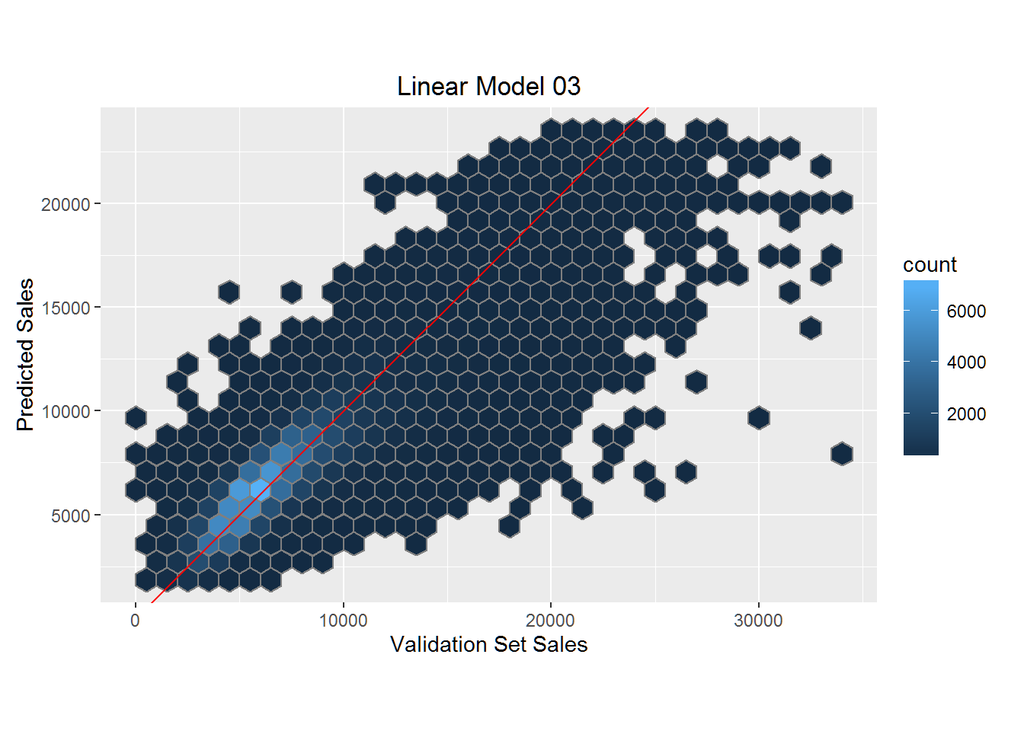

### Decision Tree

It is possible our decision boundaries are not linear. A Decision tree may be a more appropriate choice. Lets build one and see. Default parameters include complexity parameter (cp) = 0.01, minsplit = 20, minbucket = minsplit/3, maxdepth=30.

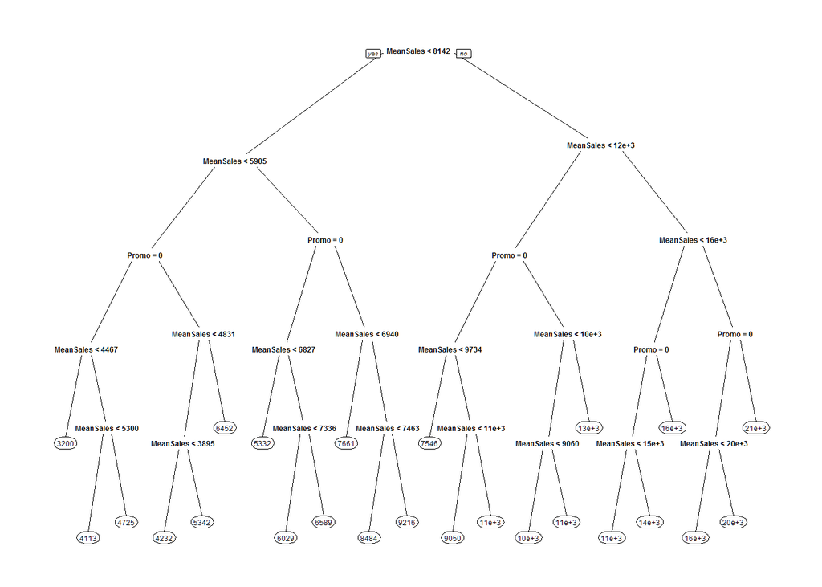

```r
dt_params = rpart.control(minsplit=21, minbucket=7, cp=0.001)
dt_model_01 <- rpart(data = trainingSet,
                     control = dt_params,
                  formula = Sales ~ DayOfWeek + Date.Month + Date.DayOfMonth + Promo + LogCompetitionDistance + CompetitionTenure + CompetitionOpened + Promo2 + PromoInterval + Promo2Tenure + Promo2Begun + StateHoliday + SchoolHoliday + StoreType + Assortment + MeanSales)

#summary(dt_model_01)
rpart.plot(dt_model_01, varlen=0, faclen=0)
```

```r
predictions_dt_model_01 <- predict(dt_model_01, validateSet)
dt01_rmspe = rmspe(predictions_dt_model_01, validateSet$Sales)
print(dt01_rmspe)
```

```
## [1] 0.2780064
```

The simple decision tree model has a RMSPE = 0.28, which is comparable to the linear model. The decision tree chooses only Promo and MeanSales for splitting the data.

### Random Forest

Random forest will run multiple decision trees with each split sampling from different data points and different features. This will hopefully yeield a more valid model. Random forest requires more computation time, but does not run the risk of overfitting. We will use a subset of the trainingSet in order to decrease our training time.

The default parameters include the number of trees to combine = 500, the number of features to try at each split = param/3, and the minimum size of nodes = 5. Random Forest does not accept categories with more than 52 levels (1,115 levels in Store), so we will use MeanSales instead of Store.

```r
tiny_trainingSet <- sample(trainingSet, 50000)
```

```r
start_time <- Sys.time()
rf_model_01 <- randomForest(Sales ~ DayOfWeek + Date.Month + Date.DayOfMonth + Promo + LogCompetitionDistance + CompetitionTenure + CompetitionOpened + Promo2 + PromoInterval + Promo2Tenure + Promo2Begun + StateHoliday + SchoolHoliday + StoreType + Assortment + MeanSales,
                            data = tiny_trainingSet,
                            importance = TRUE,
                            ntree=200,
                            nodesize=100)
run_time <- Sys.time() - start_time
print(run_time)
```

```
## Time difference of 5.329307 mins
```

```r
print(rf_model_01)
```

```
##
## Call:
##  randomForest(formula = Sales ~ DayOfWeek + Date.Month + Date.DayOfMonth +      Promo + LogCompetitionDistance + CompetitionTenure + CompetitionOpened +      Promo2 + PromoInterval + Promo2Tenure + Promo2Begun + StateHoliday +      SchoolHoliday + StoreType + Assortment + MeanSales, data = tiny_t…
##                Type of random forest: regression
##                      Number of trees: 200
## No. of variables tried at each split: 5
##
##           Mean of squared residuals: 2382696
##                     % Var explained: 75.41
```

```r
# Model performance
predictions_rf_model_01 <- predict(rf_model_01, validateSet)
rf01_rmspe = rmspe(predictions_rf_model_01, validateSet$Sales)
print(rf01_rmspe)
```

```
## [1] 0.2659042
```

For the random forest model with 200 trees, running on a subset of the training data (50,000 rows), we acheieved RMPSE = 0.26. Reducing nodesize would be ideal, but we are limited in computation time. Let’s look at the feature importance for the random forest model.

```r
# Feature importance
imp = importance(rf_model_01, type=1)
imp = data.frame(Feature=row.names(imp), Importance=imp[,1])
print(imp)
```

```
##                                       Feature Importance
## DayOfWeek                           DayOfWeek  23.481444
## Date.Month                         Date.Month  25.912997
## Date.DayOfMonth               Date.DayOfMonth  30.986120
## Promo                                   Promo 245.203340
## LogCompetitionDistance LogCompetitionDistance  21.077898
## CompetitionTenure           CompetitionTenure  21.489120
## CompetitionOpened           CompetitionOpened  14.106469
## Promo2                                 Promo2   9.221956
## PromoInterval                   PromoInterval  10.951214
## Promo2Tenure                     Promo2Tenure  12.931609
## Promo2Begun                       Promo2Begun   7.215881
## StateHoliday                     StateHoliday   1.609324
## SchoolHoliday                   SchoolHoliday  15.531696
## StoreType                           StoreType  21.182537
## Assortment                         Assortment  11.838978
## MeanSales                           MeanSales 117.770380
```

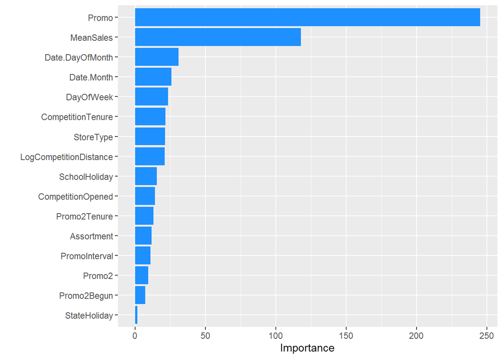

Whether or not a store has a promotion that day seems to be the most important feature. As expected, the mean sales of a particular store is also an important feature for correctly predicting sales, as are the date information, and how long the competitor has been around.

### Boosting Tree

Lets include one more model, a, eXtreme Gradient Boosting tree. Gradient Boosting Decision Trees (GBDT) have more tuninging parameters, and are prone to overfitting (unlike Random Forest), but has potential to build a better model. We are using default params for now, including learning rate = 0.3, max.depth = 6, subsample = 1, colsample = 1, min child weight = 1.

```r
# build matricies
#names(trainingSet)
feature_idx = c(3, 6:10, 12:18, 20:22) # includes MedianSales
print(names(trainingSet)[feature_idx])
```

```
##  [1] "DayOfWeek"              "Promo"
##  [3] "StateHoliday"           "SchoolHoliday"
##  [5] "StoreType"              "Assortment"
##  [7] "Promo2"                 "PromoInterval"
##  [9] "LogCompetitionDistance" "Date.DayOfMonth"
## [11] "Date.Month"             "CompetitionTenure"
## [13] "Promo2Tenure"           "MeanSales"
## [15] "CompetitionOpened"      "Promo2Begun"
```

```r
trainMatrix <- xgb.DMatrix(data=data.matrix(trainingSet[,feature_idx]), label=trainingSet$Sales, missing=NA)
validateMatrix <- xgb.DMatrix(data=data.matrix(validateSet[,feature_idx]), label=validateSet$Sales, missing=NA)
holdoutMatrix <- xgb.DMatrix(data=data.matrix(holdoutSet[,feature_idx]), label=holdoutSet$Sales, missing=NA)
```

```r
# set params
param = list(objective="reg:linear", eta=0.3, max.depth=6)

# train model
start_time <- Sys.time()
xgb_01_model <- xgb.train(params=param, data=trainMatrix, nrounds=60)
run_time <- Sys.time() - start_time
print(run_time)
```

```
## Time difference of 14.56985 secs
```

```r
# evaluation
xgb_01_predictions <- predict(xgb_01_model, validateMatrix)
xgb_01_rmspe = rmspe(xgb_01_predictions, validateSet$Sales)
print(xgb_01_rmspe)
```

```
## [1] 0.2532233
```

With only 60 rounds of the xgb model on the full training set, we already achieve a validation RMPSE = 0.253. We’ll now try tuning the parameters to improve this score.

```r
xgb_perf = data.frame(nrounds = rep(80, 4),
                      eta = c(0.001, 0.01, 0.1, 1.0),
                      max_depth = rep(6, 4),
                      time = rep(0, 4),
                      rmspe = rep(0, 4) )

for (i in 1:4) {
  param = list(objective="reg:linear", eta=xgb_perf$eta[i], max.depth=xgb_perf$max_depth[i])

  start_time <- Sys.time()
  this_xgb_model <- xgb.train(params=param, data=trainMatrix, nrounds=xgb_perf$nrounds[i])
  run_time = (Sys.time() - start_time)

  this_xgb_pred <- predict(this_xgb_model, validateMatrix)
  this_xgb_rmspe = rmspe(this_xgb_pred, validateSet$Sales)
  print(c('eta', xgb_perf$eta[i], 'rmspe', this_xgb_rmspe))
  xgb_perf$time[i] = as.numeric(run_time, units="secs")
  xgb_perf$rmspe[i] = this_xgb_rmspe
}
```

```
## [1] "eta"               "0.001"             "rmspe"
## [4] "0.919341951508785"
## [1] "eta"               "0.01"              "rmspe"
## [4] "0.443818427083493"
## [1] "eta"              "0.1"              "rmspe"
## [4] "0.25640540789116"
## [1] "eta"               "1"                 "rmspe"
## [4] "0.247991746675974"
```

Holding max_depth constant and nrounds=80, the eta that minimizes RMSPE is 1.0. For smaller eta, the learning rate is slow, so a larger number of rounds is necessary to maintain a small RMSPE. We will now run xgb models with slow learning (0.1) and many rounds.

```r
xgb_perf = data.frame(nrounds = c(10, 50, 100, 400, 800),
                      eta = rep(0.1, 5),
                      max_depth = rep(10, 5),
                      time = rep(0, 5),
                      rmspe = rep(0, 5) )

for (i in 1:5) {
  param = list(objective="reg:linear", eta=xgb_perf$eta[i], max.depth=10, subsample=0.85, colsample_bytree=0.4)

  start_time <- Sys.time()
  this_xgb_model <- xgb.train(params=param, data=trainMatrix, nrounds=xgb_perf$nrounds[i])
  run_time = (Sys.time() - start_time)

  this_xgb_pred <- predict(this_xgb_model, validateMatrix)
  this_xgb_rmspe = rmspe(this_xgb_pred, validateSet$Sales)
  print(c('nrounds', xgb_perf$nrounds[i], 'rmspe', this_xgb_rmspe))
  xgb_perf$time[i] = as.numeric(run_time, units="secs")
  xgb_perf$rmspe[i] = this_xgb_rmspe
}
```

```
## [1] "nrounds"           "10"                "rmspe"
## [4] "0.355016016639667"
## [1] "nrounds"           "50"                "rmspe"
## [4] "0.254228705764286"
## [1] "nrounds"           "100"               "rmspe"
## [4] "0.243942780868179"
## [1] "nrounds"           "400"               "rmspe"
## [4] "0.234276123368117"
## [1] "nrounds"           "800"               "rmspe"
## [4] "0.230181143183788"
```

[figure not shown]

Finally, we can compare the results of our models with our self-made holdout set.

```r
# Evaluate on holdout set
final_xgb_pred <- predict(this_xgb_model, holdoutMatrix)
final_xgb_rmspe = rmspe(final_xgb_pred, holdoutSet$Sales)
print(final_xgb_rmspe)
```

```
## [1] 0.2983069
```

We retain a RMSPE = 0.30 for the xgboost model.

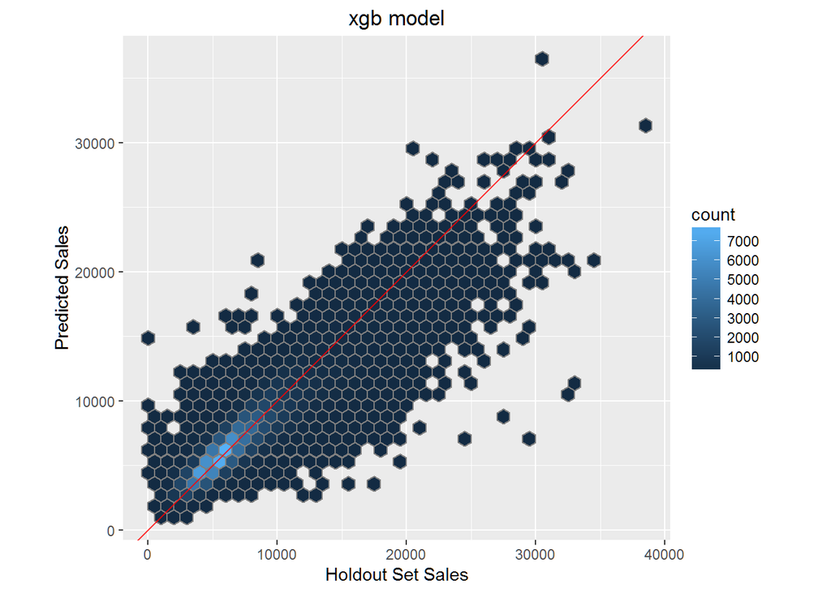

```r
# Linear model and holdout comparison
predictions_model_03 <- predict(linear_model_03, holdoutSet)
print(rmspe(predictions_model_03, holdoutSet$Sales))
```

```
## [1] 0.3279638
```

The linear model achieves RMSPE = 0.33 for the holdout set.

```r
# random forest model and holdout comparison
predictions_rf_model_01 <- predict(rf_model_01, holdoutSet)
print(rmspe(predictions_rf_model_01, holdoutSet$Sales))
```

```
## [1] 0.3226769
```

The random forest model achieves RMSPE = 0.32 for the holdout set.

# Conclusion

The best model from this work, in terms of RMSPE on the holdout set, was the xgboost model. It is likely that the tree parameters could be tuned better, and certainly the xgboost model could be run longer. Incorporating k-fold cross-validation would help prevent overfitting and yield a more consistent result with the holdout set. Additionally, the MeanSales figures were artifically lowering RMSPE in the validate set, since Sales values in the validation set went into the calculations of MeanSales. Forecasting future sales would certainly want to incorporate a MeanSales feature though. Another feature that would be useful to add is whether or not the current Date of an observation coincides with the PromoInterval month for that store.